# 11-load-rmi

## 0.1 Load libs, common functions

```r
source(knitr::purl("10-load-data.Rmd"))
```

```
processing file: 10-load-data.Rmd
```

[output not shown]

```
output file: 10-load-data.R
```

```r
fs::file_delete("10-load-data.R")
pacman::p_load(DataExplorer)
```

# 1 LDV National Stock Forecast

This contains Light Duty Vehicle (LDV) stock projections for the United States through 2050 by vehicle type. It does not contain state level stock. It will need to be grouped into RMI vehicle categories and formatted correctly.

```r
ldv_stock_natl_frcst <- read_excel("LDV_Stock_National.xlsx", skip=5)
ldv_stock_natl_frcst
```

| Vehicle Category | Fuel Type | Full name | API Key | Units | 2019 | 2020 | 2021 | 2022 | 2023 | 2024 | 2025 | 2026 | 2027 | 2028 | 2029 | 2030 | 2031 | 2032 | 2033 | 2034 | 2035 | 2036 | 2037 | 2038 | 2039 | 2040 | 2041 | 2042 | 2043 | … |
| --- | --- | --- | --- | --- | --- | --- | --- | --- | --- | --- | --- | --- | --- | --- | --- | --- | --- | --- | --- | --- | --- | --- | --- | --- | --- | --- | --- | --- | --- | --- |
| Conventional Cars | Gasoline ICE Vehicles | Light-Duty Vehicle Stock: Conventional Cars: Gasoline: High oil and gas supply | 49-AEO2020.4.highogs-d112619a | millions | 122.923447 | 122.725212 | 122.332619 | 121.839600 | 121.310242 | 120.763336 | 120.213982 | 119.610069 | 118.984802 | 118.296844 | 117.579521 | 116.884727 | 116.184120 | 115.496101 | 114.835892 | 114.231377 | 113.725227 | 113.388977 | 113.204002 | 113.205032 | 113.384552 | 113.689621 | 114.119431 | 114.662369 | 115.243675 | … |
| Conventional Cars | TDI Diesel ICE | Light-Duty Vehicle Stock: Conventional Cars: TDI Diesel: High oil and gas supply | 49-AEO2020.5.highogs-d112619a | millions | 0.749025 | 0.715220 | 0.680808 | 0.646569 | 0.612097 | 0.576981 | 0.540560 | 0.502280 | 0.461898 | 0.420983 | 0.380596 | 0.342662 | 0.309397 | 0.282006 | 0.260450 | 0.244115 | 0.232261 | 0.224907 | 0.222149 | 0.223175 | 0.226920 | 0.232605 | 0.239465 | 0.246803 | 0.254348 | … |
| Conventional Cars | Total Conventional Cars | Light-Duty Vehicle Stock: Conventional Cars: Total: High oil and gas supply | 49-AEO2020.6.highogs-d112619a | millions | 123.672470 | 123.440430 | 123.013428 | 122.486168 | 121.922340 | 121.340317 | 120.754539 | 120.112350 | 119.446701 | 118.717827 | 117.960121 | 117.227386 | 116.493515 | 115.778107 | 115.096344 | 114.475494 | 113.957489 | 113.613884 | 113.426155 | 113.428207 | 113.611473 | 113.922226 | 114.358894 | 114.909172 | 115.498024 | … |
| Alternative-Fuel Cars | Ethanol-Flex Fuel ICE | Light-Duty Vehicle Stock: Alternative-Fuel Cars: Ethanol-Flex Fuel ICE: High oil and gas supply | 49-AEO2020.9.highogs-d112619a | millions | 4.943337 | 4.923793 | 4.877738 | 4.807054 | 4.709954 | 4.589298 | 4.444169 | 4.274975 | 4.080970 | 3.871771 | 3.652374 | 3.437415 | 3.236398 | 3.050828 | 2.883717 | 2.742476 | 2.625231 | 2.529781 | 2.461304 | 2.411104 | 2.376484 | 2.354699 | 2.342421 | 2.337255 | 2.335437 | … |
| Alternative-Fuel Cars | 100 Mile Electric Vehicle | Light-Duty Vehicle Stock: Alternative-Fuel Cars: 100 Mile Electric Vehicle: High oil and gas supply | 49-AEO2020.10.highogs-d112619a | millions | 0.192995 | 0.196836 | 0.198205 | 0.198483 | 0.197726 | 0.195899 | 0.193002 | 0.188751 | 0.182894 | 0.175575 | 0.166855 | 0.156552 | 0.145825 | 0.135080 | 0.125461 | 0.116984 | 0.110027 | 0.104056 | 0.099450 | 0.096331 | 0.094662 | 0.094216 | 0.094643 | 0.095647 | 0.096923 | … |
| Alternative-Fuel Cars | 200 Mile Electric Vehicle | Light-Duty Vehicle Stock: Alternative-Fuel Cars: 200 Mile Electric Vehicle: High oil and gas supply | 49-AEO2020.11.highogs-d112619a | millions | 0.222318 | 0.227069 | 0.233612 | 0.246285 | 0.275548 | 0.341093 | 0.472901 | 0.616681 | 0.764489 | 0.916392 | 1.075458 | 1.243262 | 1.423293 | 1.617869 | 1.828079 | 2.056939 | 2.303862 | 2.572776 | 2.862367 | 3.172334 | 3.500456 | 3.843663 | 4.192331 | 4.542152 | 4.888902 | … |
| Alternative-Fuel Cars | 300 Mile Electric Vehicle | Light-Duty Vehicle Stock: Alternative-Fuel Cars: 300 Mile Electric Vehicle: High oil and gas supply | 49-AEO2020.12.highogs-d112619a | millions | 0.389339 | 0.683521 | 1.076643 | 1.467772 | 1.855499 | 2.232771 | 2.585966 | 2.928698 | 3.271312 | 3.622576 | 3.986622 | 4.373031 | 4.791107 | 5.225434 | 5.671454 | 6.124356 | 6.583696 | 7.044110 | 7.505901 | 7.971338 | 8.438104 | 8.899590 | 9.361859 | 9.826846 | 10.290887 | … |
| Alternative-Fuel Cars | Plug-in 10 Gasoline Hybrid | Light-Duty Vehicle Stock: Alternative-Fuel Cars: Plug-in 10 Gasoline Hybrid: High oil and gas supply | 49-AEO2020.13.highogs-d112619a | millions | 0.280129 | 0.281542 | 0.282268 | 0.282098 | 0.281026 | 0.279151 | 0.276411 | 0.272673 | 0.267503 | 0.260591 | 0.251485 | 0.240578 | 0.228125 | 0.214425 | 0.200248 | 0.186375 | 0.174064 | 0.163996 | 0.156417 | 0.150641 | 0.146615 | 0.144159 | 0.143116 | 0.143640 | 0.144906 | … |
| Alternative-Fuel Cars | Plug-in 40 Gasoline Hybrid | Light-Duty Vehicle Stock: Alternative-Fuel Cars: Plug-in 40 Gasoline Hybrid: High oil and gas supply | 49-AEO2020.14.highogs-d112619a | millions | 0.298861 | 0.360626 | 0.411710 | 0.453409 | 0.488429 | 0.519370 | 0.543147 | 0.565602 | 0.588031 | 0.611139 | 0.635432 | 0.663860 | 0.692840 | 0.721196 | 0.748877 | 0.775816 | 0.802782 | 0.831594 | 0.863142 | 0.897673 | 0.935579 | 0.976004 | 1.018351 | 1.062422 | 1.106871 | … |
| Alternative-Fuel Cars | Electric-Diesel Hybrid | Light-Duty Vehicle Stock: Alternative-Fuel Cars: Electric-Diesel Hybrid: High oil and gas supply | 49-AEO2020.15.highogs-d112619a | millions | 0.000000 | 0.000000 | 0.000000 | 0.000000 | 0.000000 | 0.000000 | 0.000000 | 0.000000 | 0.000000 | 0.000000 | 0.000000 | 0.001671 | 0.011169 | 0.028272 | 0.049077 | 0.071500 | 0.094638 | 0.118098 | 0.141797 | 0.165838 | 0.190145 | 0.214437 | 0.238912 | 0.263271 | 0.287024 | … |

[output cut: 28 more lines]

```r
NA
```

To clean the data, we’ll be dropping full NA columns and rows. Let’s check to see the effect of this:

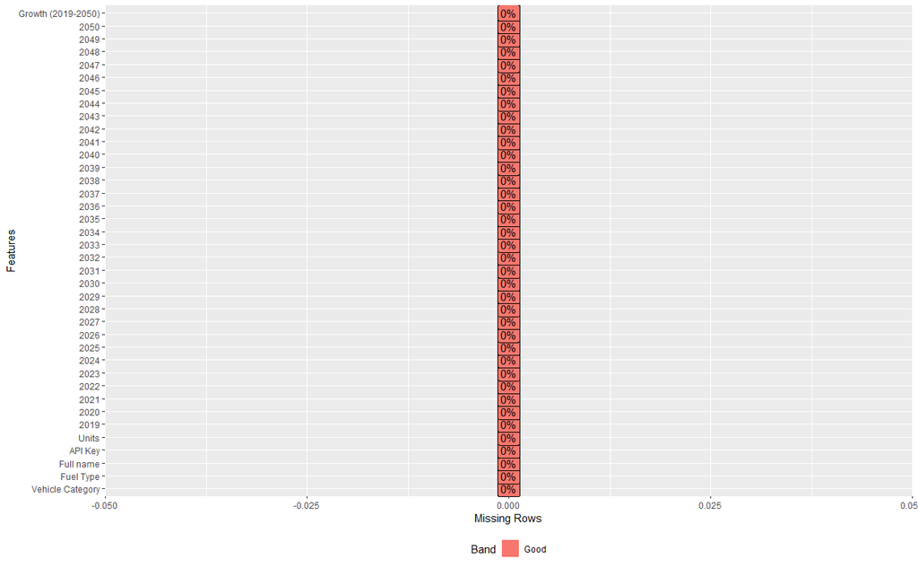

```r
plot_missing(ldv_stock_natl_frcst)
```

```r
ldv_stock_natl_frcst <- ldv_stock_natl_frcst %>%
  clean_names() %>%
  select(-growth_2019_2050, -vehicle_category, -fuel_type, -api_key, -units)

ldv_stock_natl_frcst[] <- lapply(ldv_stock_natl_frcst, gsub, pattern='Light-Duty Vehicle Stock: ', replacement='')

ldv_stock_natl_frcst
```

| full_name | x2019 | x2020 | x2021 | x2022 | x2023 | x2024 | x2025 | x2026 | x2027 | x2028 | x2029 | x2030 | x2031 | x2032 | x2033 | x2034 | x2035 | x2036 | x2037 | x2038 | x2039 | x2040 | x2041 | x2042 | x2043 | x2044 | x2045 | x2046 | x2047 | … |
| --- | --- | --- | --- | --- | --- | --- | --- | --- | --- | --- | --- | --- | --- | --- | --- | --- | --- | --- | --- | --- | --- | --- | --- | --- | --- | --- | --- | --- | --- | --- |
| Conventional Cars: Gasoline: High oil and gas supply | 122.923447 | 122.725212 | 122.332619 | 121.8396 | 121.310242 | 120.763336 | 120.213982 | 119.610069 | 118.984802 | 118.296844 | 117.579521 | 116.884727 | 116.18412 | 115.496101 | 114.835892 | 114.231377 | 113.725227 | 113.388977 | 113.204002 | 113.205032 | 113.384552 | 113.689621 | 114.119431 | 114.662369 | 115.243675 | 115.892662 | 116.636475 | 117.442566 | 118.305939 | … |
| Conventional Cars: TDI Diesel: High oil and gas supply | 0.749025 | 0.71522 | 0.680808 | 0.646569 | 0.612097 | 0.576981 | 0.54056 | 0.50228 | 0.461898 | 0.420983 | 0.380596 | 0.342662 | 0.309397 | 0.282006 | 0.26045 | 0.244115 | 0.232261 | 0.224907 | 0.222149 | 0.223175 | 0.22692 | 0.232605 | 0.239465 | 0.246803 | 0.254348 | 0.261993 | 0.26974 | 0.277436 | 0.285016 | … |
| Conventional Cars: Total: High oil and gas supply | 123.67247 | 123.44043 | 123.013428 | 122.486168 | 121.92234 | 121.340317 | 120.754539 | 120.11235 | 119.446701 | 118.717827 | 117.960121 | 117.227386 | 116.493515 | 115.778107 | 115.096344 | 114.475494 | 113.957489 | 113.613884 | 113.426155 | 113.428207 | 113.611473 | 113.922226 | 114.358894 | 114.909172 | 115.498024 | 116.154655 | 116.906212 | 117.720001 | 118.590958 | … |
| Alternative-Fuel Cars: Ethanol-Flex Fuel ICE: High oil and gas supply | 4.943337 | 4.923793 | 4.877738 | 4.807054 | 4.709954 | 4.589298 | 4.444169 | 4.274975 | 4.08097 | 3.871771 | 3.652374 | 3.437415 | 3.236398 | 3.050828 | 2.883717 | 2.742476 | 2.625231 | 2.529781 | 2.461304 | 2.411104 | 2.376484 | 2.354699 | 2.342421 | 2.337255 | 2.335437 | 2.336846 | 2.341783 | 2.349439 | 2.359509 | … |
| Alternative-Fuel Cars: 100 Mile Electric Vehicle: High oil and gas supply | 0.192995 | 0.196836 | 0.198205 | 0.198483 | 0.197726 | 0.195899 | 0.193002 | 0.188751 | 0.182894 | 0.175575 | 0.166855 | 0.156552 | 0.145825 | 0.13508 | 0.125461 | 0.116984 | 0.110027 | 0.104056 | 0.09945 | 0.096331 | 0.094662 | 0.094216 | 0.094643 | 0.095647 | 0.096923 | 0.098477 | 0.100257 | 0.102164 | 0.104175 | … |
| Alternative-Fuel Cars: 200 Mile Electric Vehicle: High oil and gas supply | 0.222318 | 0.227069 | 0.233612 | 0.246285 | 0.275548 | 0.341093 | 0.472901 | 0.616681 | 0.764489 | 0.916392 | 1.075458 | 1.243262 | 1.423293 | 1.617869 | 1.828079 | 2.056939 | 2.303862 | 2.572776 | 2.862367 | 3.172334 | 3.500456 | 3.843663 | 4.192331 | 4.542152 | 4.888902 | 5.234603 | 5.584751 | 5.935357 | 6.28917 | … |
| Alternative-Fuel Cars: 300 Mile Electric Vehicle: High oil and gas supply | 0.389339 | 0.683521 | 1.076643 | 1.467772 | 1.855499 | 2.232771 | 2.585966 | 2.928698 | 3.271312 | 3.622576 | 3.986622 | 4.373031 | 4.791107 | 5.225434 | 5.671454 | 6.124356 | 6.583696 | 7.04411 | 7.505901 | 7.971338 | 8.438104 | 8.89959 | 9.361859 | 9.826846 | 10.290887 | 10.758096 | 11.231628 | 11.713227 | 12.197652 | … |
| Alternative-Fuel Cars: Plug-in 10 Gasoline Hybrid: High oil and gas supply | 0.280129 | 0.281542 | 0.282268 | 0.282098 | 0.281026 | 0.279151 | 0.276411 | 0.272673 | 0.267503 | 0.260591 | 0.251485 | 0.240578 | 0.228125 | 0.214425 | 0.200248 | 0.186375 | 0.174064 | 0.163996 | 0.156417 | 0.150641 | 0.146615 | 0.144159 | 0.143116 | 0.14364 | 0.144906 | 0.146659 | 0.148786 | 0.151003 | 0.153292 | … |
| Alternative-Fuel Cars: Plug-in 40 Gasoline Hybrid: High oil and gas supply | 0.298861 | 0.360626 | 0.41171 | 0.453409 | 0.488429 | 0.51937 | 0.543147 | 0.565602 | 0.588031 | 0.611139 | 0.635432 | 0.66386 | 0.69284 | 0.721196 | 0.748877 | 0.775816 | 0.802782 | 0.831594 | 0.863142 | 0.897673 | 0.935579 | 0.976004 | 1.018351 | 1.062422 | 1.106871 | 1.152041 | 1.198291 | 1.244221 | 1.290074 | … |
| Alternative-Fuel Cars: Electric-Diesel Hybrid: High oil and gas supply | 0 | 0 | 0 | 0 | 0 | 0 | 0 | 0 | 0 | 0 | 0 | 0.001671 | 0.011169 | 0.028272 | 0.049077 | 0.0715 | 0.094638 | 0.118098 | 0.141797 | 0.165838 | 0.190145 | 0.214437 | 0.238912 | 0.263271 | 0.287024 | 0.310151 | 0.332647 | 0.354135 | 0.374292 | … |

[output cut: 28 more lines]

# 2 LDV Fuel Economy Forecast

This contains Light Duty Vehicle (LDV) fuel economy projections for the United States through 2050 by vehicle type. It does not consider information at the state level. It will need to be grouped into RMI vehicle categories and formatted correctly.

```r
ldv_fuel_econ <- read_excel("LDV_Fuel_Economy.xlsx", skip=5)
```

```
* `` -> ...1
```

```r
ldv_fuel_econ
```

| ...1 | 2019 | 2020 | 2021 | 2022 | 2023 | 2024 | 2025 | 2026 | 2027 | 2028 | 2029 | 2030 | 2031 | 2032 | 2033 | 2034 | 2035 | 2036 | 2037 | 2038 | 2039 | 2040 | 2041 | 2042 | 2043 | 2044 | 2045 | 2046 | 2047 | … |
| --- | --- | --- | --- | --- | --- | --- | --- | --- | --- | --- | --- | --- | --- | --- | --- | --- | --- | --- | --- | --- | --- | --- | --- | --- | --- | --- | --- | --- | --- | --- |
| Conventional Cars: Gasoline mpg gas equiv | 40.15686 | 40.91232 | 42.22183 | 44.30971 | 46.17293 | 47.33552 | 49.47162 | 49.48781 | 49.40371 | 49.32623 | 49.24857 | 49.20063 | 49.18652 | 49.13999 | 49.09003 | 49.02932 | 48.96162 | 48.87134 | 48.79066 | 48.71286 | 48.63032 | 48.54691 | 48.47191 | 48.39758 | 48.31452 | 48.22761 | 48.13923 | 48.05166 | 47.96095 | … |
| Conventional Cars: TDI Diesel mpg gas equiv | 50.41479 | 50.89672 | 51.83246 | 53.37029 | 54.77209 | 55.80742 | 58.26621 | 58.18019 | 58.11145 | 58.02894 | 57.95874 | 57.94185 | 57.85796 | 57.80043 | 57.76357 | 57.71926 | 57.65232 | 57.58922 | 57.51376 | 57.42382 | 57.33592 | 57.24800 | 57.16746 | 57.08066 | 56.88722 | 56.67397 | 56.45931 | 56.22912 | 56.00427 | … |
| Alternative-Fuel Cars: Ethanol-Flex Fuel ICE mpg gas equiv | 40.84162 | 41.65236 | 43.03331 | 45.20683 | 47.09663 | 48.25688 | 50.63771 | 50.65227 | 50.57786 | 50.50444 | 50.43372 | 50.40458 | 50.38112 | 50.35295 | 50.31904 | 50.27301 | 50.21236 | 50.13711 | 50.06681 | 49.99296 | 49.91796 | 49.84005 | 49.76845 | 49.69657 | 49.61471 | 49.52855 | 49.44430 | 49.35450 | 49.26657 | … |
| Alternative-Fuel Cars: 100 Mile Electric Vehicle mpg gas equiv | 111.42800 | 112.43616 | 114.81964 | 117.42063 | 120.54676 | 122.39338 | 125.22186 | 125.25935 | 125.25964 | 125.24074 | 125.21903 | 125.21136 | 125.19214 | 125.19682 | 125.22407 | 125.26413 | 125.29343 | 125.34434 | 125.37876 | 125.39598 | 125.42291 | 125.44669 | 125.45152 | 125.46573 | 125.48174 | 125.49420 | 125.50528 | 125.51062 | 125.51791 | … |
| Alternative-Fuel Cars: 200 Mile Electric Vehicle mpg gas equiv | 121.63172 | 122.88335 | 124.71987 | 127.03785 | 129.61789 | 131.05319 | 133.65082 | 133.84547 | 133.79442 | 133.68242 | 133.60934 | 133.60796 | 133.46777 | 133.45247 | 133.44649 | 133.45288 | 133.44247 | 133.47356 | 133.49171 | 133.50116 | 133.51578 | 133.53145 | 133.54575 | 133.54884 | 133.54778 | 133.55453 | 133.57927 | 133.57756 | 133.60239 | … |
| Alternative-Fuel Cars: 300 Mile Electric Vehicle mpg gas equiv | 120.73607 | 121.32538 | 122.80615 | 125.19575 | 127.54622 | 128.72641 | 132.20294 | 132.11766 | 132.00780 | 131.90103 | 131.80174 | 131.70448 | 131.59412 | 131.50481 | 131.41489 | 131.34886 | 131.29208 | 131.25464 | 131.22006 | 131.19012 | 131.16907 | 131.15465 | 131.14293 | 131.12797 | 131.11371 | 131.10255 | 131.09442 | 131.07971 | 131.07202 | … |
| Alternative-Fuel Cars: Plug-in 10 Gasoline Hybrid mpg gas equiv | 61.00252 | 61.20949 | 62.03635 | 63.80302 | 68.39467 | 69.75680 | 73.39916 | 75.23128 | 75.15583 | 74.97853 | 74.90403 | 74.91661 | 74.73960 | 74.64843 | 74.58013 | 74.51691 | 74.41740 | 74.35847 | 74.30364 | 74.21157 | 74.13908 | 74.07094 | 74.01437 | 73.94453 | 73.85729 | 73.76971 | 73.68509 | 73.56651 | 73.47668 | … |
| Alternative-Fuel Cars: Plug-in 40 Gasoline Hybrid mpg gas equiv | 74.51688 | 74.46134 | 75.11223 | 76.92622 | 80.87019 | 82.37322 | 85.53870 | 87.01884 | 87.06033 | 87.01721 | 86.98055 | 86.98158 | 86.76405 | 86.60799 | 86.50181 | 86.41104 | 86.30492 | 86.23849 | 86.17060 | 86.08476 | 86.01104 | 85.94691 | 85.89241 | 85.82229 | 85.73923 | 85.65933 | 85.58511 | 85.48075 | 85.40701 | … |
| Alternative-Fuel Cars: Electric-Diesel Hybrid mpg gas equiv | 0.00000 | 0.00000 | 0.00000 | 0.00000 | 0.00000 | 0.00000 | 0.00000 | 0.00000 | 0.00000 | 0.00000 | 0.00000 | 84.79720 | 84.84476 | 84.97545 | 84.97558 | 84.90356 | 84.77306 | 84.65205 | 84.53225 | 84.40280 | 84.27531 | 84.11857 | 83.89987 | 83.71102 | 83.63343 | 83.55788 | 83.44611 | 83.29192 | 83.13971 | … |
| Alternative-Fuel Cars: Electric-Gasoline Hybrid mpg gas equiv | 57.71697 | 58.27427 | 60.24955 | 63.54940 | 66.29323 | 67.66206 | 73.32799 | 73.33603 | 73.16547 | 72.99852 | 72.82284 | 72.62926 | 72.40184 | 72.13341 | 71.95189 | 71.80320 | 71.68160 | 71.56741 | 71.47014 | 71.34785 | 71.24118 | 71.13028 | 70.96893 | 70.87216 | 70.77286 | 70.66338 | 70.54144 | 70.41716 | 70.28532 | … |

[output cut: 32 more lines]

```r
NA
```

To clean the data, we’ll be dropping full NA columns and rows. Let’s check to see the effect of this:

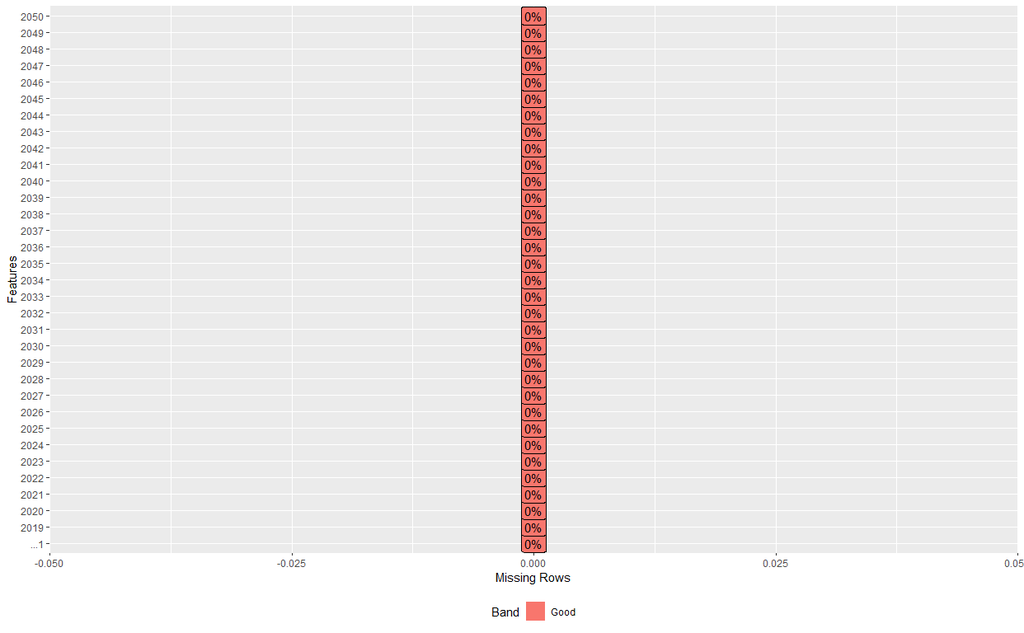

```r
plot_missing(ldv_fuel_econ)
```

Looks like there’s no NA columns or rows. There are no redundant columns nor is any data formatted incorrectly. The vehicle type column is renamed to match the last df.

```r
ldv_fuel_econ <- ldv_fuel_econ %>%
  clean_names() %>% rename(full_name = x1)

ldv_fuel_econ
```

| full_name | x2019 | x2020 | x2021 | x2022 | x2023 | x2024 | x2025 | x2026 | x2027 | x2028 | x2029 | x2030 | x2031 | x2032 | x2033 | x2034 | x2035 | x2036 | x2037 | x2038 | x2039 | x2040 | x2041 | x2042 | x2043 | x2044 | x2045 | x2046 | x2047 | … |
| --- | --- | --- | --- | --- | --- | --- | --- | --- | --- | --- | --- | --- | --- | --- | --- | --- | --- | --- | --- | --- | --- | --- | --- | --- | --- | --- | --- | --- | --- | --- |
| Conventional Cars: Gasoline mpg gas equiv | 40.15686 | 40.91232 | 42.22183 | 44.30971 | 46.17293 | 47.33552 | 49.47162 | 49.48781 | 49.40371 | 49.32623 | 49.24857 | 49.20063 | 49.18652 | 49.13999 | 49.09003 | 49.02932 | 48.96162 | 48.87134 | 48.79066 | 48.71286 | 48.63032 | 48.54691 | 48.47191 | 48.39758 | 48.31452 | 48.22761 | 48.13923 | 48.05166 | 47.96095 | … |
| Conventional Cars: TDI Diesel mpg gas equiv | 50.41479 | 50.89672 | 51.83246 | 53.37029 | 54.77209 | 55.80742 | 58.26621 | 58.18019 | 58.11145 | 58.02894 | 57.95874 | 57.94185 | 57.85796 | 57.80043 | 57.76357 | 57.71926 | 57.65232 | 57.58922 | 57.51376 | 57.42382 | 57.33592 | 57.24800 | 57.16746 | 57.08066 | 56.88722 | 56.67397 | 56.45931 | 56.22912 | 56.00427 | … |
| Alternative-Fuel Cars: Ethanol-Flex Fuel ICE mpg gas equiv | 40.84162 | 41.65236 | 43.03331 | 45.20683 | 47.09663 | 48.25688 | 50.63771 | 50.65227 | 50.57786 | 50.50444 | 50.43372 | 50.40458 | 50.38112 | 50.35295 | 50.31904 | 50.27301 | 50.21236 | 50.13711 | 50.06681 | 49.99296 | 49.91796 | 49.84005 | 49.76845 | 49.69657 | 49.61471 | 49.52855 | 49.44430 | 49.35450 | 49.26657 | … |
| Alternative-Fuel Cars: 100 Mile Electric Vehicle mpg gas equiv | 111.42800 | 112.43616 | 114.81964 | 117.42063 | 120.54676 | 122.39338 | 125.22186 | 125.25935 | 125.25964 | 125.24074 | 125.21903 | 125.21136 | 125.19214 | 125.19682 | 125.22407 | 125.26413 | 125.29343 | 125.34434 | 125.37876 | 125.39598 | 125.42291 | 125.44669 | 125.45152 | 125.46573 | 125.48174 | 125.49420 | 125.50528 | 125.51062 | 125.51791 | … |
| Alternative-Fuel Cars: 200 Mile Electric Vehicle mpg gas equiv | 121.63172 | 122.88335 | 124.71987 | 127.03785 | 129.61789 | 131.05319 | 133.65082 | 133.84547 | 133.79442 | 133.68242 | 133.60934 | 133.60796 | 133.46777 | 133.45247 | 133.44649 | 133.45288 | 133.44247 | 133.47356 | 133.49171 | 133.50116 | 133.51578 | 133.53145 | 133.54575 | 133.54884 | 133.54778 | 133.55453 | 133.57927 | 133.57756 | 133.60239 | … |
| Alternative-Fuel Cars: 300 Mile Electric Vehicle mpg gas equiv | 120.73607 | 121.32538 | 122.80615 | 125.19575 | 127.54622 | 128.72641 | 132.20294 | 132.11766 | 132.00780 | 131.90103 | 131.80174 | 131.70448 | 131.59412 | 131.50481 | 131.41489 | 131.34886 | 131.29208 | 131.25464 | 131.22006 | 131.19012 | 131.16907 | 131.15465 | 131.14293 | 131.12797 | 131.11371 | 131.10255 | 131.09442 | 131.07971 | 131.07202 | … |
| Alternative-Fuel Cars: Plug-in 10 Gasoline Hybrid mpg gas equiv | 61.00252 | 61.20949 | 62.03635 | 63.80302 | 68.39467 | 69.75680 | 73.39916 | 75.23128 | 75.15583 | 74.97853 | 74.90403 | 74.91661 | 74.73960 | 74.64843 | 74.58013 | 74.51691 | 74.41740 | 74.35847 | 74.30364 | 74.21157 | 74.13908 | 74.07094 | 74.01437 | 73.94453 | 73.85729 | 73.76971 | 73.68509 | 73.56651 | 73.47668 | … |
| Alternative-Fuel Cars: Plug-in 40 Gasoline Hybrid mpg gas equiv | 74.51688 | 74.46134 | 75.11223 | 76.92622 | 80.87019 | 82.37322 | 85.53870 | 87.01884 | 87.06033 | 87.01721 | 86.98055 | 86.98158 | 86.76405 | 86.60799 | 86.50181 | 86.41104 | 86.30492 | 86.23849 | 86.17060 | 86.08476 | 86.01104 | 85.94691 | 85.89241 | 85.82229 | 85.73923 | 85.65933 | 85.58511 | 85.48075 | 85.40701 | … |
| Alternative-Fuel Cars: Electric-Diesel Hybrid mpg gas equiv | 0.00000 | 0.00000 | 0.00000 | 0.00000 | 0.00000 | 0.00000 | 0.00000 | 0.00000 | 0.00000 | 0.00000 | 0.00000 | 84.79720 | 84.84476 | 84.97545 | 84.97558 | 84.90356 | 84.77306 | 84.65205 | 84.53225 | 84.40280 | 84.27531 | 84.11857 | 83.89987 | 83.71102 | 83.63343 | 83.55788 | 83.44611 | 83.29192 | 83.13971 | … |
| Alternative-Fuel Cars: Electric-Gasoline Hybrid mpg gas equiv | 57.71697 | 58.27427 | 60.24955 | 63.54940 | 66.29323 | 67.66206 | 73.32799 | 73.33603 | 73.16547 | 72.99852 | 72.82284 | 72.62926 | 72.40184 | 72.13341 | 71.95189 | 71.80320 | 71.68160 | 71.56741 | 71.47014 | 71.34785 | 71.24118 | 71.13028 | 70.96893 | 70.87216 | 70.77286 | 70.66338 | 70.54144 | 70.41716 | 70.28532 | … |

[output cut: 32 more lines]